# Matplotlib: US Cumulative GDP Growth, Population Growth (2013-2017)

**Source data**: State GDP: BEA (chained 2009 dollars), MSA Population (Census, Apr 2010 - July 2017)

This was also an exercise to see if I could get my speed up faster than just doing this in Excel. It's not, but you really can't beat the fact that this is basically putting together a research report in Word plus making Excel charts at the same time. And that's pretty awesome!

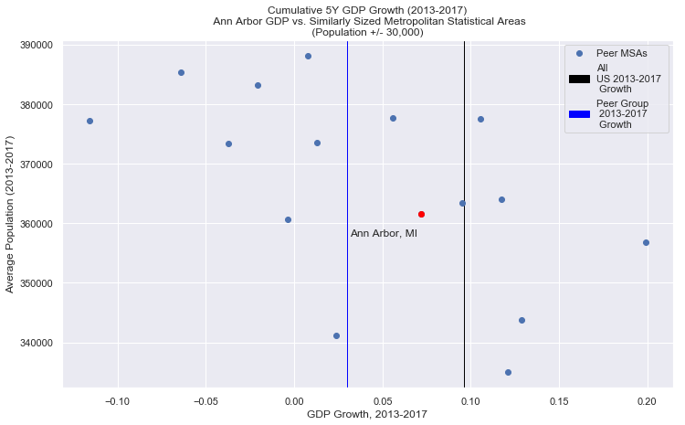

```python
import pandas as pd
import numpy as np
import matplotlib.pyplot as plt
import seaborn as sns

# importing the population and gdp data
metro_pop = pd.read_csv("https://raw.githubusercontent.com/stuffofminsun/CouseraAppliedPlotting/master"
                        "/cbsa-est2017-alldata.csv", encoding='cp1252')
metro_gdp = pd.read_csv("https://raw.githubusercontent.com/stuffofminsun/CouseraAppliedPlotting/master"
                        "/metropolitanareaschainedgdp.csv", skiprows=4, delimiter=',')

# cleaning up GDP
metro_gdp.drop(metro_gdp.index[-4:], inplace=True)
metro_gdp.drop(['GeoFips', '2001', '2002', '2003', '2004', '2005', '2006', '2007', '2008', '2009',
                '2010', '2011', '2012', '2014', '2015', '2016'], axis = 1, inplace=True)
metro_gdp['5Y Change'] = (metro_gdp['2017']/metro_gdp['2013'])-1
metro_gdp['GeoName'] = metro_gdp['GeoName'].str.replace(r" \(.*\)","")
metro_gdp.set_index('GeoName', inplace=True)

# cleaning up population and getting average population per area based on 2010-2017 estimates
column_names = ['POPESTIMATE2013', 'POPESTIMATE2014', 'POPESTIMATE2015', 'POPESTIMATE2016', 'POPESTIMATE2017']
metro_pop_all = metro_pop[metro_pop['LSAD'] == 'Metropolitan Statistical Area']
metro_pop['AVGPOPESTIMATE'] = metro_pop_all[column_names].mean(axis=1)
metro_pop = metro_pop[['NAME', 'AVGPOPESTIMATE']]
metro_pop.set_index('NAME', inplace=True)

combined = pd.merge(metro_gdp, metro_pop, how='inner', left_index=True, right_index=True)
blah  = pd.merge(metro_gdp, metro_pop, how='left', left_index=True, right_index=True)
annarbor_upperrange = combined[combined.index == 'Ann Arbor, MI']['AVGPOPESTIMATE'].values[0] + 30000
annarbor_lowerrange = combined[combined.index == 'Ann Arbor, MI']['AVGPOPESTIMATE'].values[0] - 30000
combined = combined[combined['AVGPOPESTIMATE'] < annarbor_upperrange]
combined = combined[combined['AVGPOPESTIMATE'] > annarbor_lowerrange]
combined.sort_values('AVGPOPESTIMATE', inplace=True)

# calculating peer group growth
group_2013 = combined['2013'].sum()
group_2017 = combined['2017'].sum()
group_5Y = (group_2017/group_2013)-1

# charting
sns.set()
fig, ax = plt.subplots(figsize=(12,7))

plt.title('Cumulative 5Y GDP Growth (2013-2017)\n Ann Arbor GDP vs. Similarly Sized Metropolitan Statistical '
          'Areas\n (Population +/- 30,000) ')
plt.ylabel('Average Population (2013-2017)')
plt.xlabel('GDP Growth, 2013-2017')
plt.plot(combined['5Y Change'], combined['AVGPOPESTIMATE'], 'o', label='Peer MSAs')
plt.plot(combined[combined.index == 'Ann Arbor, MI']['5Y Change'].values[0],
         combined[combined.index == 'Ann Arbor, MI']['AVGPOPESTIMATE'].values[0], 'o', color='red')

plt.annotate('Ann Arbor, MI', (combined[combined.index == 'Ann Arbor, MI']['5Y Change'].values[0]-.04,
         combined[combined.index == 'Ann Arbor, MI']['AVGPOPESTIMATE'].values[0]-3500))

# set 5Y GDP growth for United States & peer group
plt.axvspan(0.095968, 0.095968, color='black', label='All \nUS 2013-2017 \n Growth')
plt.axvspan(group_5Y, group_5Y, color='blue', label='Peer Group \n 2013-2017 \n Growth')
plt.legend(loc='best')
plt.show()
```

After looking at Ann Arbor, was curious to see if cumulative GDP growth was related to population size and split the entire MSA group up into quintiles and did a not so quick chart. Annotating matplotlib charts is the bane of my existence. I probably didn't have to chart this in a scatter plot, a bar chart would've probably been better.

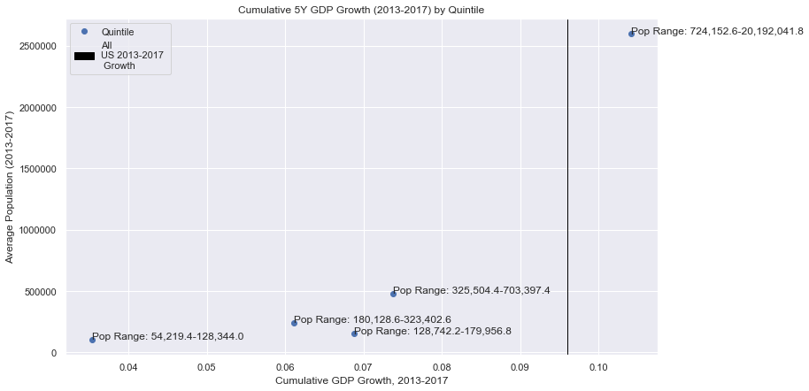

```python
all_combined = pd.merge(metro_gdp, metro_pop, how='inner', left_index=True, right_index=True)
all_combined['Quintile'] = pd.qcut(all_combined['AVGPOPESTIMATE'], 5, labels=False)
quintiles = all_combined.groupby('Quintile').agg({'2013': 'sum', '2017': 'sum', '5Y Change': 'mean',
                                                  'AVGPOPESTIMATE': ['mean', np.min, np.max]})
quintiles.columns = ['2013', '2017', '5Y Change', 'AVGPOPESTIMATE', 'Minimum Pop', 'Maximum Pop']
quintiles['5Y Change'] = quintiles['2017']/quintiles['2013']-1

fig, ax = plt.subplots(figsize=(12,7))
plt.title('Cumulative 5Y GDP Growth (2013-2017) by Quintile')
plt.ylabel('Average Population (2013-2017)')
plt.xlabel('Cumulative GDP Growth, 2013-2017')

plt.plot(quintiles['5Y Change'], quintiles['AVGPOPESTIMATE'], 'o', label='Quintile')
for i in range(5):
    plt.annotate("Pop Range: {:,}-{:,}".format(quintiles[quintiles.index==i]['Minimum Pop'].values[0],
                                     quintiles[quintiles.index==i]['Maximum Pop'].values[0]),
                 (quintiles[quintiles.index==i]['5Y Change'].values[0],
                  quintiles[quintiles.index==i]['AVGPOPESTIMATE'].values[0]))

plt.axvspan(0.095968, 0.095968, color='black', label='All \nUS 2013-2017 \n Growth')
plt.legend(loc='best')
plt.show()
```

Decided to check on correlation between population growth and GDP growth and changed the dataframe slightly to include cumulative population growth instead of just using an average (which had been specifically for charting the first chart).

```python
metro_pop_growth = metro_pop_all[['NAME', 'POPESTIMATE2013', 'POPESTIMATE2017']].copy()
metro_pop_growth['5Y Pop Growth'] = metro_pop_growth['POPESTIMATE2017']/metro_pop_all['POPESTIMATE2013']-1
metro_pop_growth.set_index('NAME', inplace=True)
growth = pd.merge(metro_gdp, metro_pop_growth, how='inner', left_index=True, right_index=True)
growth.drop(['2013', '2017', 'POPESTIMATE2013', 'POPESTIMATE2017'], axis=1, inplace=True)
growth.columns = ['5Y GDP Growth', '5Y Pop Growth']
growth.corr()
```

|  | 5Y GDP Growth | 5Y Pop Growth |
| --- | --- | --- |
| 5Y GDP Growth | 1.000000 | 0.590581 |
| 5Y Pop Growth | 0.590581 | 1.000000 |